# ACA4 Social Network Analysis

### Group members: Ruoqi(Mark) Wang, Jingxuan Liao, Yuchen(Rebecca) Wu

Survey introduction: In this project, we designed an online survey about participants' past international (specifically the U.S and Canada) airline choices. We distributed it to our friends through Wechat. The survey contained two questions, one question asked about the English name, another one was formatted in the multiple choice question asking participant to choose the airline company that they have chose in the past journey to and from China to the U.S or Canada.

```python
import pandas as pd
import openpyxl
import matplotlib.pyplot as plt
```

#### Data Collection

After a total of 21 participants finished the survey, we export the survey result directly from the Tencent survey platform in a excel format.

#### Data Cleaning

In order to transform original excel sheet into an adjacency matrix, we directly use excel function to achieve it. Here is result after transformation.

```python
data = pd.read_excel('ACA4 data .xlsx',engine='openpyxl',index_col = 0)
data
```

|  | Vino | Eva | Tommy | Myra | Rapunzel | Aria | YiHou | Emily | Feng Lin | victor | ... | Cecilia | Lexie | Sindy | Ruby | Ylan | jenny | Kkk | Katie | Mark | Wendy |
| --- | --- | --- | --- | --- | --- | --- | --- | --- | --- | --- | --- | --- | --- | --- | --- | --- | --- | --- | --- | --- | --- |
| Vino | 0 | 6 | 4 | 1 | 3 | 2 | 2 | 0 | 4 | 0 | ... | 3 | 4 | 5 | 4 | 0 | 4 | 4 | 4 | 2 | 3 |
| Eva | 6 | 0 | 5 | 1 | 4 | 3 | 3 | 1 | 4 | 1 | ... | 6 | 5 | 7 | 6 | 0 | 7 | 6 | 5 | 5 | 4 |
| Tommy | 4 | 5 | 0 | 1 | 4 | 3 | 1 | 0 | 3 | 1 | ... | 3 | 4 | 5 | 2 | 0 | 3 | 3 | 4 | 1 | 3 |
| Myra | 1 | 1 | 1 | 0 | 1 | 1 | 0 | 0 | 1 | 0 | ... | 1 | 1 | 1 | 1 | 0 | 1 | 1 | 1 | 0 | 1 |
| Rapunzel | 3 | 4 | 4 | 1 | 0 | 3 | 1 | 0 | 3 | 1 | ... | 2 | 3 | 5 | 3 | 0 | 4 | 3 | 3 | 0 | 3 |
| Aria | 2 | 3 | 3 | 1 | 3 | 0 | 1 | 0 | 2 | 1 | ... | 3 | 3 | 3 | 3 | 0 | 3 | 3 | 3 | 0 | 2 |
| YiHou | 2 | 3 | 1 | 0 | 1 | 1 | 0 | 1 | 2 | 0 | ... | 1 | 2 | 2 | 2 | 1 | 3 | 2 | 2 | 2 | 2 |
| Emily | 0 | 1 | 0 | 0 | 0 | 0 | 1 | 0 | 0 | 0 | ... | 0 | 0 | 0 | 1 | 1 | 1 | 1 | 0 | 1 | 0 |
| Feng Lin | 4 | 4 | 3 | 1 | 3 | 2 | 2 | 0 | 0 | 0 | ... | 2 | 2 | 2 | 1 | 0 | 2 | 1 | 2 | 1 | 2 |
| victor | 0 | 1 | 1 | 0 | 1 | 1 | 0 | 0 | 0 | 0 | ... | 1 | 1 | 1 | 0 | 0 | 0 | 1 | 1 | 0 | 1 |
| Jess | 4 | 6 | 4 | 1 | 4 | 3 | 2 | 0 | 2 | 1 | ... | 4 | 5 | 6 | 5 | 0 | 4 | 4 | 5 | 1 | 3 |
| Cecilia | 3 | 6 | 3 | 1 | 2 | 3 | 1 | 0 | 2 | 1 | ... | 0 | 4 | 4 | 2 | 0 | 3 | 3 | 4 | 2 | 3 |
| Lexie | 4 | 5 | 4 | 1 | 3 | 3 | 2 | 0 | 2 | 1 | ... | 4 | 0 | 5 | 2 | 0 | 3 | 4 | 5 | 1 | 4 |
| Sindy | 5 | 7 | 5 | 1 | 5 | 3 | 2 | 0 | 2 | 1 | ... | 4 | 5 | 0 | 3 | 0 | 6 | 4 | 5 | 1 | 4 |
| Ruby | 4 | 6 | 2 | 1 | 3 | 3 | 2 | 1 | 1 | 0 | ... | 2 | 2 | 3 | 0 | 1 | 5 | 4 | 2 | 2 | 2 |
| Ylan | 0 | 2 | 0 | 0 | 0 | 0 | 1 | 1 | 0 | 0 | ... | 0 | 0 | 0 | 1 | 0 | 1 | 1 | 0 | 1 | 0 |
| jenny | 4 | 7 | 3 | 1 | 4 | 3 | 3 | 1 | 2 | 0 | ... | 3 | 3 | 6 | 5 | 1 | 0 | 3 | 3 | 2 | 3 |
| Kkk | 4 | 6 | 3 | 1 | 3 | 3 | 2 | 1 | 1 | 1 | ... | 3 | 4 | 4 | 4 | 1 | 3 | 0 | 4 | 2 | 3 |
| Katie | 4 | 5 | 4 | 1 | 3 | 3 | 2 | 9 | 2 | 1 | ... | 4 | 5 | 5 | 2 | 0 | 3 | 4 | 0 | 1 | 4 |
| Mark | 2 | 5 | 1 | 0 | 0 | 0 | 2 | 1 | 1 | 0 | ... | 2 | 1 | 1 | 2 | 1 | 2 | 2 | 1 | 0 | 1 |
| Wendy | 3 | 4 | 3 | 1 | 3 | 2 | 2 | 0 | 2 | 1 | ... | 3 | 4 | 4 | 2 | 0 | 3 | 3 | 4 | 1 | 0 |

21 rows × 21 columns

#### Visualization of the network

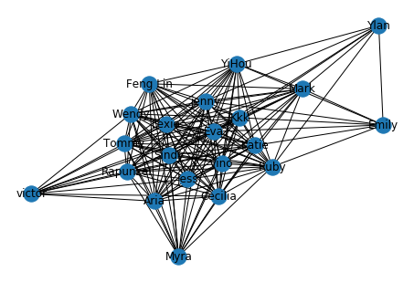

```python
import networkx as nx

G = nx.Graph(data)
nx.draw(G, with_labels=True)
```

#### Definition and Interpretation of the network:

Definition: This is a network of friends that is connected through individual airlines choices/past flight experience. The nodes are 21 participants' name took part in the survey. The edges are drawn with the number of common airlines between each two edge.

Interpretation: We can assume participants' potential connection with one another, and their orientation towards certain airlines. The number of edges each node has represents the number of participants who have chosen the same airline. Thus, the more edges one node has, the greater diversity of airlines one took in relation to others, and the greater probability one will choose either airline in the future(less predictive of choosing a certain airline). On the other hand, the less edge one has, the more predictive of its airline preference.

```python
density = nx.density(G)
print('The edge density is:','%.3f' % (density))
```

```
The edge density is: 0.829
```

```python
degree = nx.degree(G)
degree
```

```
DegreeView({'Vino': 17, 'Eva': 20, 'Tommy': 18, 'Myra': 15, 'Rapunzel': 17, 'Aria': 17, 'YiHou': 18, 'Emily': 8, 'Feng Lin': 17, 'victor': 11, 'Jess': 18, 'Cecilia': 18, 'Lexie': 18, 'Sindy': 18, 'Ruby': 19, 'Ylan': 7, 'jenny': 19, 'Kkk': 20, 'Katie': 19, 'Mark': 16, 'Wendy': 18})
```

```python
pd.DataFrame(degree).sort_values(by=1,ascending=False)
```

|  | 0 | 1 |
| --- | --- | --- |
| 1 | Eva | 20 |
| 17 | Kkk | 20 |
| 18 | Katie | 19 |
| 16 | jenny | 19 |
| 14 | Ruby | 19 |
| 10 | Jess | 18 |
| 13 | Sindy | 18 |
| 12 | Lexie | 18 |
| 11 | Cecilia | 18 |
| 20 | Wendy | 18 |
| 6 | YiHou | 18 |
| 2 | Tommy | 18 |
| 8 | Feng Lin | 17 |
| 5 | Aria | 17 |
| 4 | Rapunzel | 17 |
| 0 | Vino | 17 |
| 19 | Mark | 16 |
| 3 | Myra | 15 |
| 9 | victor | 11 |
| 7 | Emily | 8 |
| 15 | Ylan | 7 |

From the above dataframe, we count the total number of intersection of airlines one has taken in relation to other participants in the survey. As we can see, Eva, Kkk, and Katie have the highest intersections with other participants in past airlines choices.

```python
close=nx.closeness_centrality(G)
pd.DataFrame.from_dict(close,orient='index').sort_values(by=0,ascending=False)
```

|  | 0 |
| --- | --- |
| Eva | 1.000000 |
| Kkk | 1.000000 |
| Katie | 0.952381 |
| jenny | 0.952381 |
| Ruby | 0.952381 |
| Jess | 0.909091 |
| Sindy | 0.909091 |
| Lexie | 0.909091 |
| Cecilia | 0.909091 |
| Wendy | 0.909091 |
| YiHou | 0.909091 |
| Tommy | 0.909091 |
| Feng Lin | 0.869565 |
| Aria | 0.869565 |
| Rapunzel | 0.869565 |
| Vino | 0.869565 |
| Mark | 0.833333 |
| Myra | 0.800000 |
| victor | 0.689655 |
| Emily | 0.625000 |
| Ylan | 0.606061 |

From the above dataframe, closeness centrality measures "how quickly" each node (participant) can travel to the rest of the graph. We can see that eva and kkk has the highest centrality.

```python
between = nx.betweenness_centrality(G)
pd.DataFrame.from_dict(between, orient = 'index').sort_values(by=0,ascending=False)
```

|  | 0 |
| --- | --- |
| Kkk | 0.029362 |
| Eva | 0.029362 |
| jenny | 0.021520 |
| Ruby | 0.021520 |
| YiHou | 0.018396 |
| Katie | 0.015540 |
| Mark | 0.013784 |
| Jess | 0.004963 |
| Cecilia | 0.004963 |
| Sindy | 0.004963 |
| Lexie | 0.004963 |
| Wendy | 0.004963 |
| Tommy | 0.004963 |
| Aria | 0.003222 |
| Rapunzel | 0.003222 |
| Feng Lin | 0.001508 |
| Vino | 0.001508 |
| Emily | 0.000752 |
| victor | 0.000000 |
| Ylan | 0.000000 |
| Myra | 0.000000 |

Lets' see how many communities we can detect by using 'greedy_modularity_communities()'

```python
from networkx.algorithms.community.modularity_max import greedy_modularity_communities
c = list(greedy_modularity_communities(G))
len(c)
```

```
1
```

We only get 1 community with all the participants.

Now we changed the edge depending on the weight it has. We can obtain the weight of each edge using 'get_edge_attributes()'. Also, we are making the width of the edge as 2**e/100 for clear representation of difference.

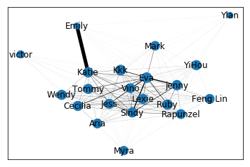

```python
eWeight = nx.get_edge_attributes(G,'weight')

nx.draw_networkx_nodes(G, pos = pos, nodelist = dict(degree).keys(), node_size = [v * 10 for v in dict(degree).values()], label = True)
nx.draw_networkx_edges(G,pos, width = [2**e/100 for e in eWeight.values()])
nx.draw_networkx_labels(G, pos=pos)

plt.show()
```